# Morphological plasticity of *Pseudofurnishius murcianus*

Katja Oselj (maintainer), Emilia Jarochowska, Luka Gale, Tea Kolar-Jurkovsek, Bogdan Jurkovsek, Goncalo Silverio, Carlos Martinez-Perez

2026-07-21

# Import data

```r
# Load required libraries
library(dplyr)
library(vegan)
library(geomorph)
library(dunn.test)
library(egg)
library(ggpubr)
library(dplyr)
library(pairwiseAdonis)
library(tidyr)
```

```r
library(ggplot2)


set.seed(42)

#### Import landmarks and specimen information ####

tps_file = "data/All_sections.TPS"

# Import landmarks from TPS file
landmarks <- geomorph::readland.tps(tps_file, specID = "ID", readcurves = TRUE)
```

```
##
##  141 curve points detected per specimen and are appended to fixed landmarks.
```

```r
# Import specimen information from CSV
specimen_info <- read.csv("data/Specimens_info.csv", header = TRUE)

#### Data cleaning and preparation ####

specimen_info$Region <- trimws(specimen_info$Region)

# Clean specimen IDs: trim whitespace and unify case
specimen_info$ID <- specimen_info$ID %>%
  trimws() %>%
  toupper()

tps_ids <- dimnames(landmarks)[[3]] %>%
  trimws() %>%
  toupper()

dimnames(landmarks)[[3]] <- tps_ids

# Check for unmatched specimen IDs
missing_in_csv <- tps_ids[!tps_ids %in% specimen_info$ID]
missing_in_tps <- specimen_info$ID[!specimen_info$ID %in% tps_ids]

if (length(missing_in_csv) > 0) {
  cat("TPS specimen IDs NOT found in Specimens_info.csv:\n")
  print(missing_in_csv)
}

if (length(missing_in_tps) > 0) {
  cat("Specimens_info.csv IDs NOT found in TPS:\n")
  print(missing_in_tps)
}

# Stop if any missing IDs to avoid misalignment
if (length(missing_in_csv) > 0 || length(missing_in_tps) > 0) {
  stop("Mismatch between TPS IDs and specimen_info IDs. Please fix and rerun.")
}

# Match specimen_info order to TPS specimen IDs
match_rows <- match(tps_ids, specimen_info$ID)
specimen_info_matched <- specimen_info[match_rows, ]
rm(tps_ids)
rm(missing_in_csv)
rm(missing_in_tps)
rm(match_rows)


#### Geometric morphometric preprocessing ####

# Define sliding landmarks
sliders <- geomorph::define.sliders(3:138)
# Perform Generalized Procrustes Analysis (GPA)
landmarks.gpa <- geomorph::gpagen(landmarks, curves = sliders)
```

[output not shown]

```r
# Perform PCA on GPA-aligned coordinates
PCA <- geomorph::gm.prcomp(landmarks.gpa$coords)
```

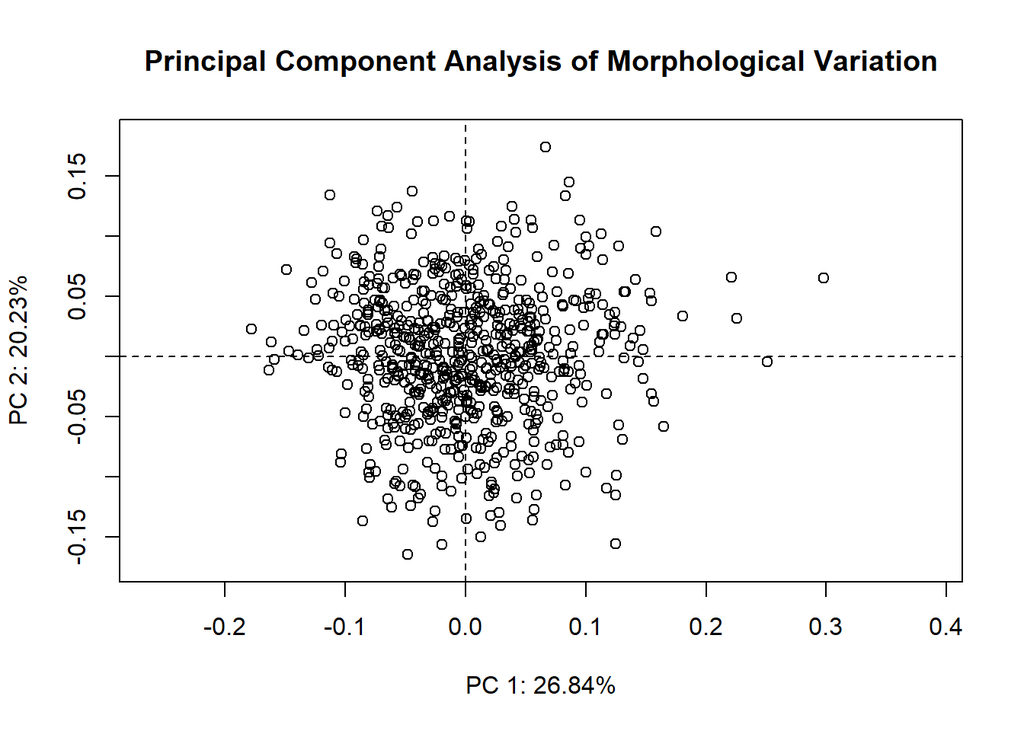

Principal component analysis (PCA) of *Pseudofurnishius murcianus* morphological variation based on informative principal components.

```r
plot(PCA, main = "Principal Component Analysis of Morphological Variation")
```

```r
# Calculate mean shape
msho <- geomorph::mshape(landmarks.gpa$coords)

#### Calculate mean distances and combine data ####

source("src/calculate_distance.R")
source("src/process_data.R")

lengths <- process_data(tps_file)

# Combine all data
data_combined <- specimen_info_matched %>%
  dplyr::left_join(lengths, by = "ID")

# Add PCA scores
data_combined$PC1 <- PCA$x[, 1]
data_combined$PC2 <- PCA$x[, 2]
data_combined$PC3 <- PCA$x[, 3]
data_combined$PC4 <- PCA$x[, 4]
data_combined$PC5 <- PCA$x[, 5]
data_combined$PC6 <- PCA$x[, 6]
data_combined$PC7 <- PCA$x[, 7]

all_pcs <- PCA$x
```

```r
# After GUENSER et al., 2022
doPcaSignif <- function(eigvals) {

  acron <- character()
  criterion <- character()
  nsigncomp <- numeric()
  n <- length(eigvals)

  # Percentage variance explained
  pcvars <- 100 * eigvals / sum(eigvals)

  # Broken stick model
  bsm <- data.frame(j = seq_len(n), p = 0)
  bsm$p[1] <- 1 / n
  for(i in 2:n){
    bsm$p[i] <- bsm$p[i - 1] + (1 / (n + 1 - i))
  }
  bsm$p <- 100 * bsm$p / n
  bsvars <- rev(bsm$p)

  acron <- "BSM"
  criterion <- "Broken stick model"
  nsigncomp <- sum(pcvars >= bsvars)

  data.frame(acron, criterion, nsigncomp)
}

# Eigenvalues from your geomorph PCA
pcasign <- doPcaSignif(PCA$d^2)

print(pcasign)
```

```
##   acron          criterion nsigncomp
## 1   BSM Broken stick model         6
```

```r
# Plot Eigenvalues of first 20 PCs, to visualise
eigvals_all <- (PCA$d)^2

# Number of PCs to display
npcs <- min(20, length(eigvals_all))

eigvals <- eigvals_all[1:npcs]

# % variance explained
pcvars <- 100 * eigvals / sum(eigvals_all)

# Broken-stick expectations
n <- length(eigvals_all)

bsvars_all <- sapply(1:n, function(i) {
  100 * sum(1/(i:n))/n
})

bsvars <- bsvars_all[1:npcs]
```

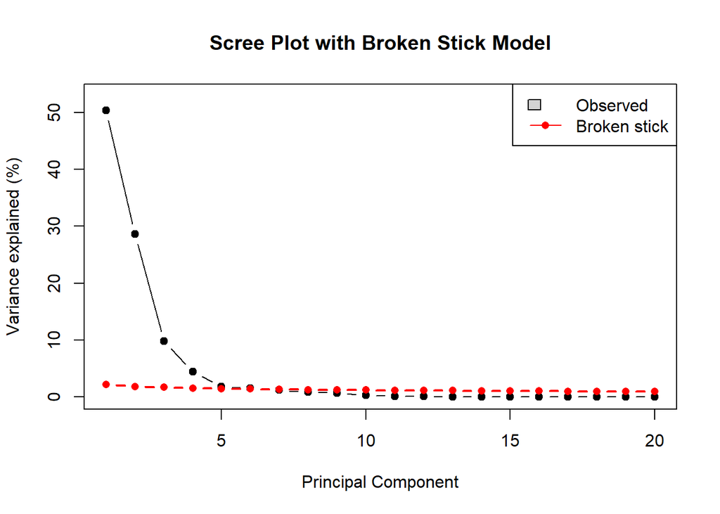

Scree Plot with Broken Stick Model

```r
plot(pcvars, type = "b", pch = 19,
     xlab = "Principal Component",
     ylab = "Variance explained (%)",
     xlim = c(1, npcs),
     ylim = c(0, max(pcvars, bsvars) * 1.05),
     main = "Scree Plot with Broken Stick Model")

lines(bsvars, type = "b", pch = 16, col = "red", lwd = 2)
legend("topright",
       legend = c("Observed", "Broken stick"),
       fill = c("lightgrey", NA),
       border = c("black", NA),
       lty = c(NA, 1),
       pch = c(NA, 16),
       col = c("black", "red"))
```

```r
informative_pcs <- PCA$x[, 1:pcasign$nsigncomp]

data_combined <- cbind(
  data_combined,
  informative_pcs
)

PC_scores <- data_combined[, c("Comp1", "Comp2", "Comp3",
                               "Comp4", "Comp5", "Comp6")]


#### Define Region based on Section ####

data_combined$Region <- as.character(data_combined$Region)
data_combined$Region[data_combined$Section %in% c("Henarejos","Libros","Bugarra")] <- "Western"
data_combined$Region[data_combined$Section %in% c("Prikrnica", "Drežnica")] <- "Northeastern"


#### Define factor orders and color schemes ####

# Define Section colors and custom order
section_order <- c("Henarejos", "Libros", "Bugarra", "Prikrnica", "Drežnica")
Region_order <- c("Western", "Northeastern")
FaciesZone_order <- c("FZ8", "FZ3")
data_combined$Section <- factor(data_combined$Section, levels = section_order)
data_combined$Region <- factor(data_combined$Region, levels = Region_order)
data_combined$FaciesZone <- factor(data_combined$FaciesZone, levels = FaciesZone_order)
data_combined$Chirality <- factor(data_combined$Chirality,levels = c("L", "R"), labels = c("Sinistral", "Dextral"))

# Color palettes
colors_list <- list(
  FaciesZone = c("FZ8" = "#fc8d59", "FZ3" = "#91bfdb"),
  Country = c("Slovenia" = "grey", "Bosnia and Herzegovina" = "#0033A0", "Spain" = "#D81B60"),
  Region = c("Western" = "#fc8d59", "Northeastern" = "#91bfdb"),
  Chirality = c("Sinistral" = "#fc8d59", "Dextral" = "#91bfdb" ),
  Section = c(
    "Henarejos" = "#fc8d59",
    "Libros" = "#fee090",
    "Bugarra" = "#ffffbf",
    "Prikrnica" = "darkblue",
    "Drežnica" = "#4575b4"
  )
)


# Create chirality grouping factor
specimen_info_matched$Chirality <- factor(ifelse(specimen_info_matched$Chirality == "R", "Dextral", "Sinistral"))

#### Save all processed data and objects ####
save(
  landmarks, specimen_info_matched, landmarks.gpa, PCA, msho,
  data_combined, colors_list,
  file = "data/processed_data.RData"
)
```

After importing the data and performing Principal Component Analysis, we examined which PCs were informative. This was achieved by a Broken-Stick Model (BSM; Barton & David 1956; Frontier 1976, using a code by Guenser et al. 2022) It turned out that, in our case, the first six PCs were informative.

Folowing tabel show how much % each PC is explainig.

| Principal Component | Variance explained (%) | Cumulative variance explained (%) |
| --- | --- | --- |
| PC1 | 26.84% | 26.84% |
| PC2 | 20.23% | 47.07% |
| PC3 | 11.82% | 58.90% |
| PC4 | 7.98% | 66.87% |
| PC5 | 5.08% | 71.96% |
| PC6 | 4.74% | 76.69% |

# Exploratory Data Analysis

## Length

### Chirality

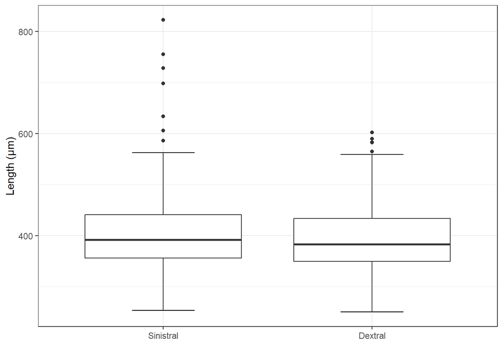

Boxplot showing the distribution of Length across Chirality

```r
ggplot(data = data_combined, aes(x = Chirality, y = Length)) +
  stat_boxplot(geom = 'errorbar', width = 0.3) +
  geom_boxplot() +
  labs(x = "", y = "Length (µm)") +
  theme_bw()
```

```
## Ignoring unknown labels:
## • ylab : ""
```

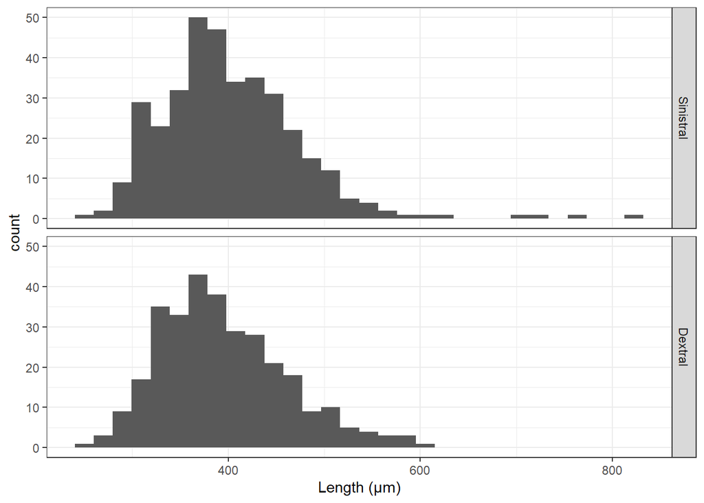

Histogram showing the distribution of Length across Chirality

```r
data_combined %>%
  ggplot(., aes(Length)) +
  geom_histogram() +
  labs(x = "Length (µm)", ylab = "") +
  theme_bw() +
  facet_grid(Chirality ~ .)
```

### Region

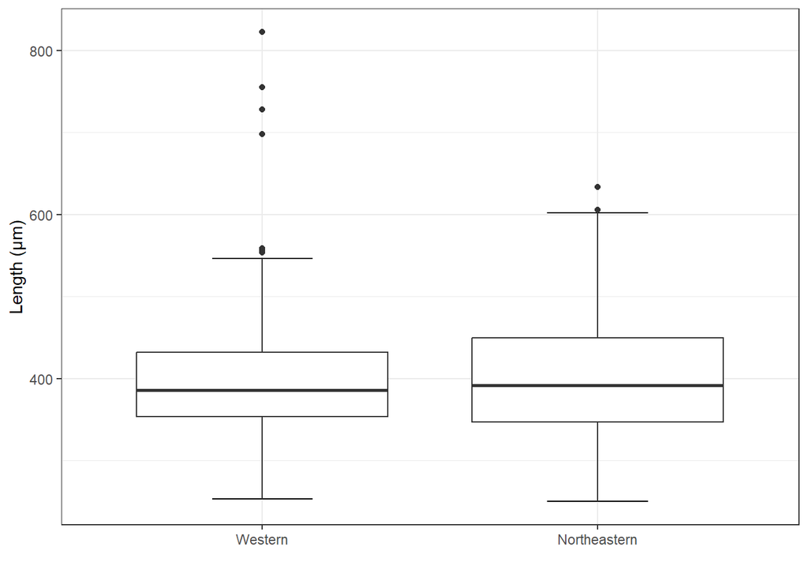

Boxplot showing the distribution of Length across region/FZ

```r
ggplot(data = data_combined, aes(x = Region, y = Length)) +
  stat_boxplot(geom = 'errorbar', width = 0.3) +
  geom_boxplot() +
  labs(x = "", y = "Length (µm)") +
  theme_bw()
```

```
## Ignoring unknown labels:
## • ylab : ""
```

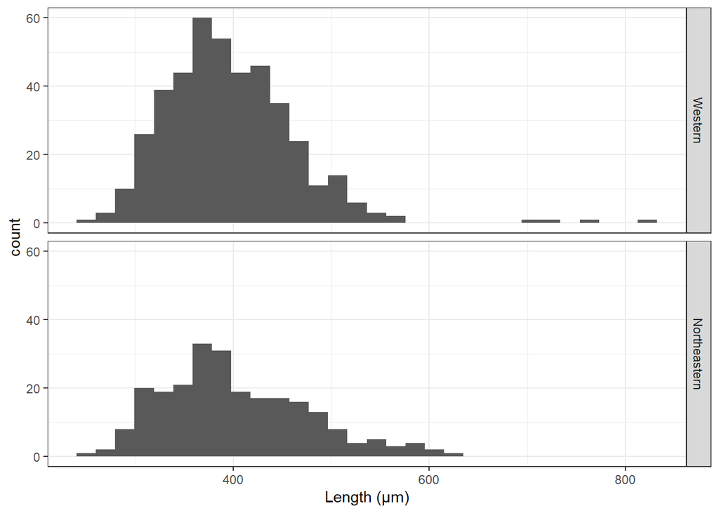

Histogram showing the distribution of Length across region/FZ

```r
data_combined %>%
  ggplot(., aes(Length)) +
  geom_histogram() +
  labs(x = "Length (µm)", ylab = "") +
  theme_bw() +
  facet_grid(Region ~ .)
```

### Section

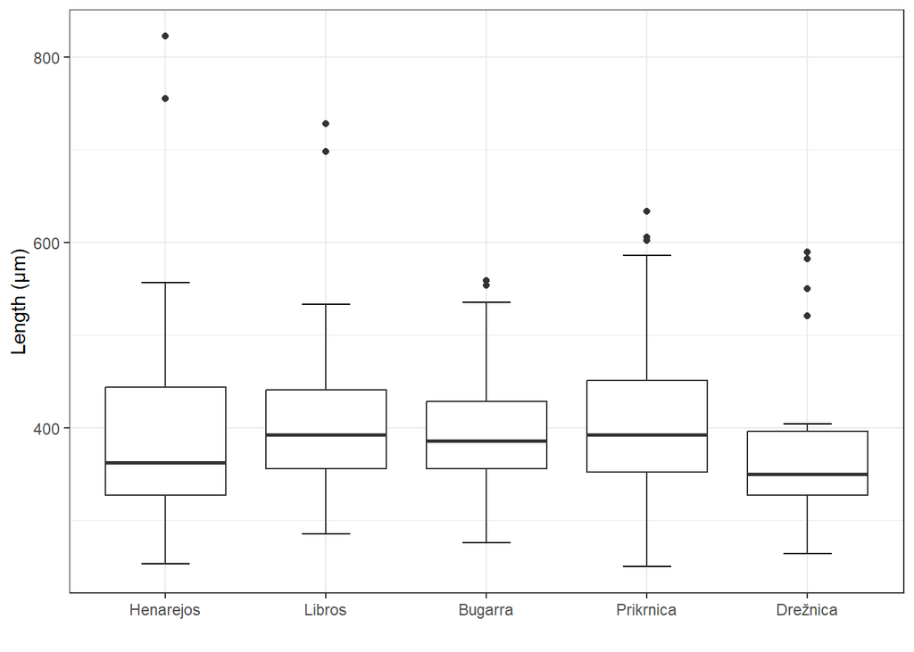

Boxplot showing the distribution of Length across section

```r
ggplot(data = data_combined, aes(x = Section, y = Length)) +
  stat_boxplot(geom = 'errorbar', width = 0.3) +
  geom_boxplot() +
  labs(x = "", y = "Length (µm)") +
  theme_bw()
```

```
## Ignoring unknown labels:
## • ylab : ""
```

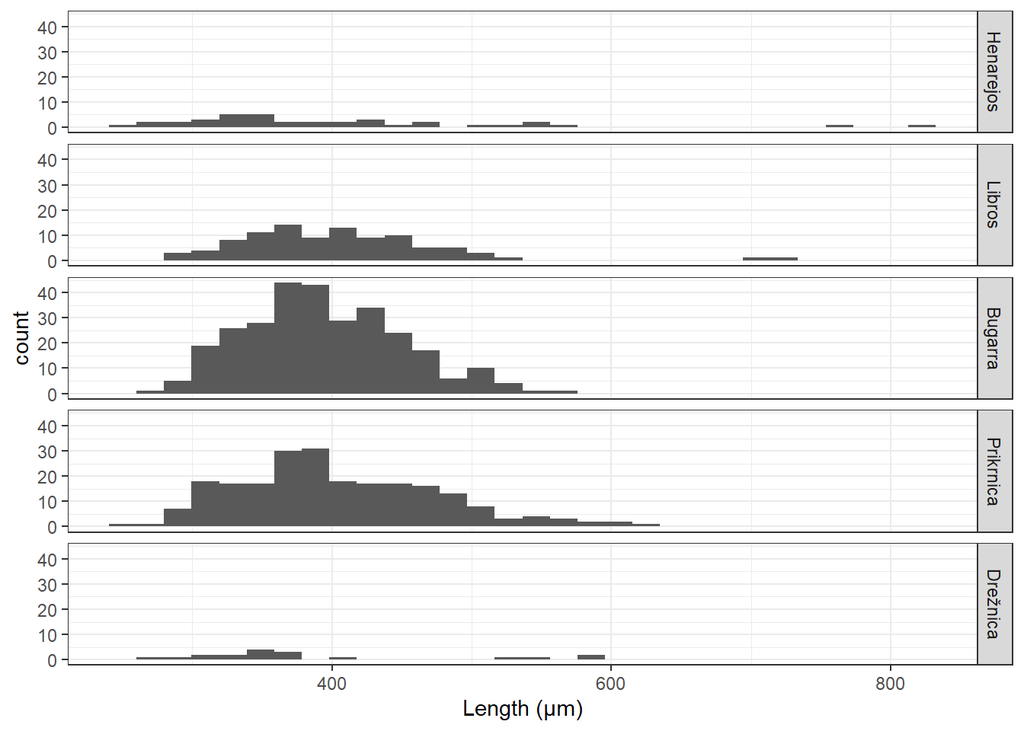

Histogram showing the distribution of Length across section

```r
data_combined %>%
  ggplot(., aes(Length)) +
  geom_histogram() +
  labs(x = "Length (µm)", ylab = "") +
  theme_bw() +
  facet_grid(Section ~ .)
```

### Statistical test of normality

```r
shapiro.test(data_combined$Length)
```

```
##
##  Shapiro-Wilk normality test
##
## data:  data_combined$Length
## W = 0.94351, p-value = 2.761e-15
```

```r
data_combined %>%
  group_by(Chirality) %>%
  summarise(
    W = shapiro.test(as.numeric(Length))$statistic,
    p_value = shapiro.test(as.numeric(Length))$p.value
  )
```

```
## # A tibble: 2 × 3
##   Chirality     W  p_value
##   <fct>     <dbl>    <dbl>
## 1 Sinistral 0.918 4.31e-13
## 2 Dextral   0.971 8.14e- 6
```

```r
data_combined %>%
  group_by(Region) %>%
  summarise(
    W = shapiro.test(as.numeric(Length))$statistic,
    p_value = shapiro.test(as.numeric(Length))$p.value
  )
```

```
## # A tibble: 2 × 3
##   Region           W  p_value
##   <fct>        <dbl>    <dbl>
## 1 Western      0.913 6.48e-15
## 2 Northeastern 0.970 4.85e- 5
```

```r
data_combined %>%
  group_by(Section) %>%
  summarise(
    W = shapiro.test(as.numeric(Length))$statistic,
    p_value = shapiro.test(as.numeric(Length))$p.value
  )
```

```
## # A tibble: 5 × 3
##   Section       W     p_value
##   <fct>     <dbl>       <dbl>
## 1 Henarejos 0.842 0.000103
## 2 Libros    0.891 0.000000777
## 3 Bugarra   0.982 0.000898
## 4 Prikrnica 0.976 0.000598
## 5 Drežnica  0.817 0.00269
```

Regardless of whether we analyse length as a variable across the entire dataset or within individual groups (chirality, regions and section), it does not follow a normal distribution, as all p-values of Shapiro test are lower than 0.05.

## Informative PCs

### Chirality

```r
counts_Chirality <- data_combined %>%
  dplyr::group_by(Chirality) %>%
  dplyr::summarise(Count = dplyr::n(), .groups = "drop") %>%
  dplyr::arrange(Chirality)

print(counts_Chirality)
```

```
## # A tibble: 2 × 2
##   Chirality Count
##   <fct>     <int>
## 1 Sinistral   360
## 2 Dextral     310
```

```r
bd_chirality <- betadisper(dist(PC_scores), group = data_combined$Chirality)
set.seed(42)
permutest(bd_chirality, permutations = 9999)
```

```
##
## Permutation test for homogeneity of multivariate dispersions
## Permutation: free
## Number of permutations: 9999
##
## Response: Distances
##            Df  Sum Sq    Mean Sq      F N.Perm Pr(>F)
## Groups      1 0.00024 0.00024401 0.1443   9999 0.7095
## Residuals 668 1.12954 0.00169093
```

```r
tapply(
  bd_chirality$distances,
  bd_chirality$group,
  mean
)
```

```
##  Sinistral    Dextral
## 0.09856171 0.09977206
```

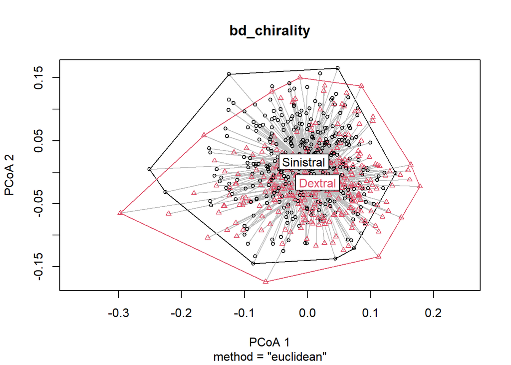

Dispersion of elements by their chirality

```r
plot(bd_chirality)
```

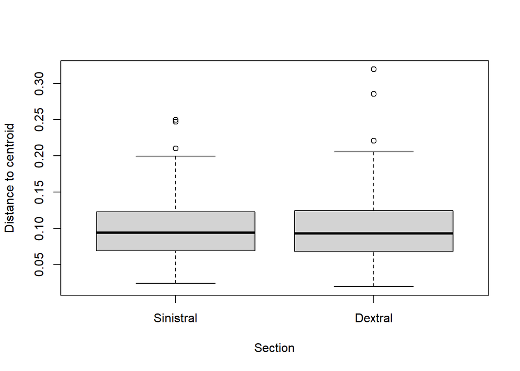

Within-chirality morphological disparity

```r
boxplot(
  bd_chirality$distances ~ bd_chirality$group,
  ylab = "Distance to centroid",
  xlab = "Section")
```

The differences in dispersion between chirality is not significant.

### Region

```r
counts_Region_chirality <- data_combined %>%
  dplyr::group_by(Region, Chirality) %>%
  dplyr::summarise(Count = dplyr::n(), .groups = "drop") %>%
  dplyr::arrange(Region, Chirality)

print(counts_Region_chirality)
```

```
## # A tibble: 4 × 3
##   Region       Chirality Count
##   <fct>        <fct>     <int>
## 1 Western      Sinistral   232
## 2 Western      Dextral     194
## 3 Northeastern Sinistral   128
## 4 Northeastern Dextral     116
```

#### Sinistral

```r
bd_Sinistral_Region <- betadisper(
  dist(PC_scores[specimen_info_matched$Chirality == "Sinistral", ]),
  group = specimen_info_matched$Region[specimen_info_matched$Chirality == "Sinistral"]
)
set.seed(42)
permutest(bd_Sinistral_Region)
```

```
##
## Permutation test for homogeneity of multivariate dispersions
## Permutation: free
## Number of permutations: 999
##
## Response: Distances
##            Df  Sum Sq   Mean Sq      F N.Perm Pr(>F)
## Groups      1 0.01270 0.0127042 8.5615    999  0.005 **
## Residuals 358 0.53123 0.0014839
## ---
## Signif. codes:  0 '***' 0.001 '**' 0.01 '*' 0.05 '.' 0.1 ' ' 1
```

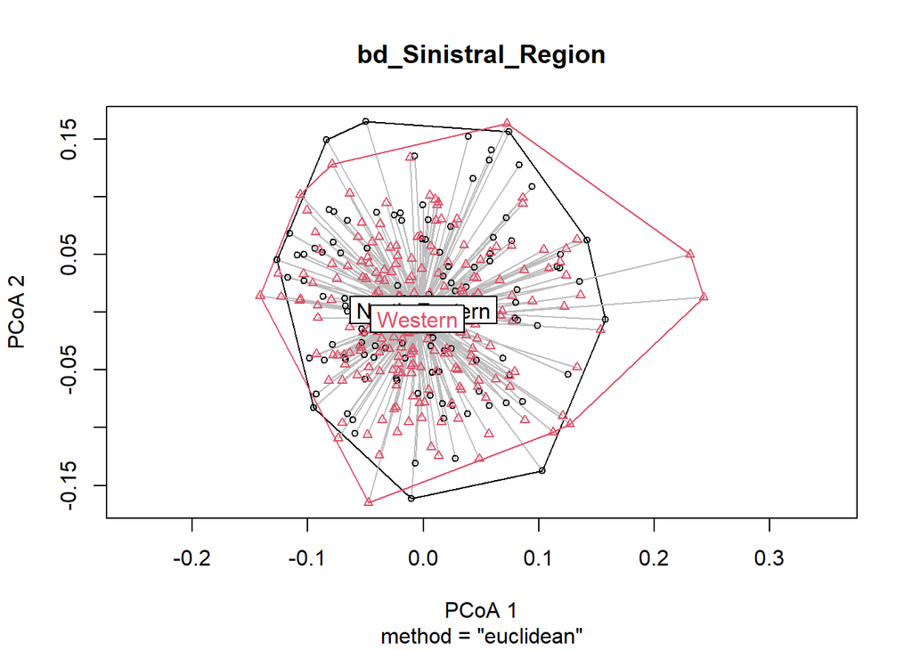

Dispersion of sinistral elements by region

```r
plot(bd_Sinistral_Region)
```

```r
tapply(
  bd_Sinistral_Region$distances,
  bd_Sinistral_Region$group,
  mean
)
```

```
## North-Eastern       Western
##    0.10608749    0.09367736
```

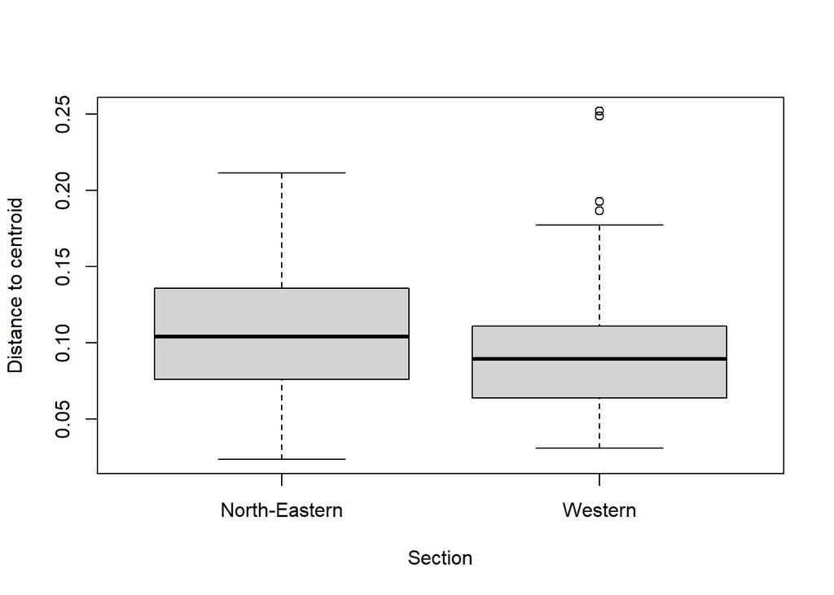

Within-region morphological disparity of sinistral elements

```r
boxplot(
  bd_Sinistral_Region$distances ~ bd_Sinistral_Region$group,
  ylab = "Distance to centroid",
  xlab = "Section")
```

The differences in dispersion between regions is significant. Whereas specimens from NE region show greater within-group dispersion (mean distance to centroids = 0.1061) compared to W region (mean distance to centroids = 0.0937).

#### Dextral

```r
bd_Dextral_Region <- betadisper(
  dist(PC_scores[specimen_info_matched$Chirality == "Dextral", ]),
  group = specimen_info_matched$Region[specimen_info_matched$Chirality == "Dextral"]
)
set.seed(42)
permutest(bd_Dextral_Region)
```

```
##
## Permutation test for homogeneity of multivariate dispersions
## Permutation: free
## Number of permutations: 999
##
## Response: Distances
##            Df  Sum Sq   Mean Sq    F N.Perm Pr(>F)
## Groups      1 0.00275 0.0027485 1.53    999  0.221
## Residuals 308 0.55329 0.0017964
```

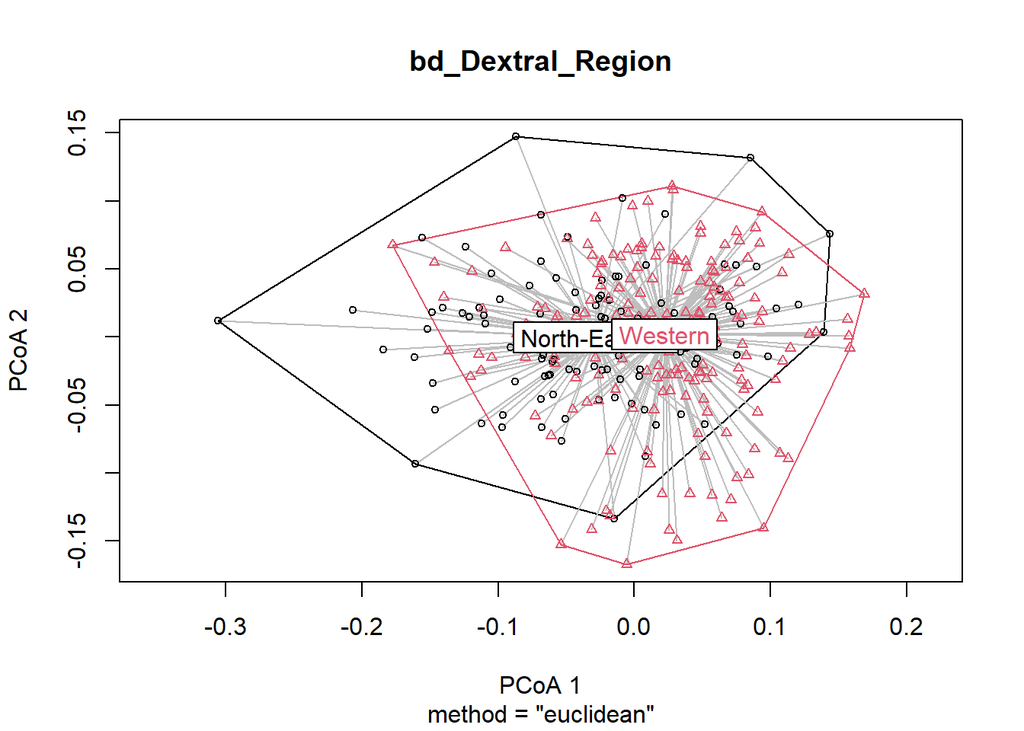

Dispersion of dextral elements by region

```r
plot(bd_Dextral_Region)
```

```r
tapply(
  bd_Dextral_Region$distances,
  bd_Dextral_Region$group,
  mean
)
```

```
## North-Eastern       Western
##    0.10088362    0.09473044
```

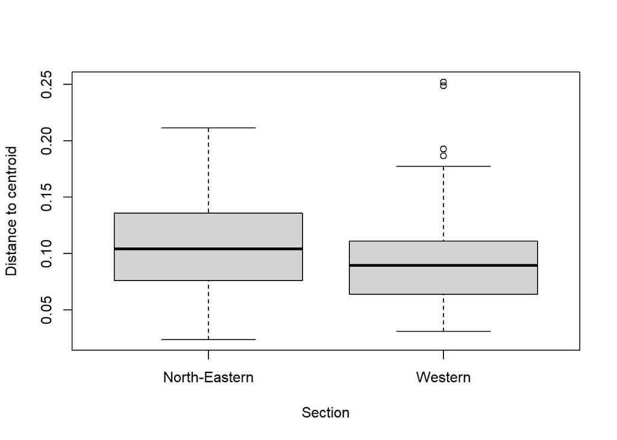

Within-region morphological disparity of sinistral elements

```r
boxplot(
  bd_Sinistral_Region$distances ~ bd_Sinistral_Region$group,
  ylab = "Distance to centroid",
  xlab = "Section")
```

The differences in dispersion between regions in dextral elements is not significant, meaning the assumption of homogeneity is meet.

### Section

```r
counts_Section <- data_combined %>%
dplyr::group_by(Section, Chirality) %>%
  dplyr::summarise(Count = dplyr::n(), .groups = "drop") %>%
  dplyr::arrange(Section)

print(counts_Section)
```

```
## # A tibble: 10 × 3
##    Section   Chirality Count
##    <fct>     <fct>     <int>
##  1 Henarejos Sinistral    18
##  2 Henarejos Dextral      19
##  3 Libros    Sinistral    58
##  4 Libros    Dextral      39
##  5 Bugarra   Sinistral   156
##  6 Bugarra   Dextral     136
##  7 Prikrnica Sinistral   118
##  8 Prikrnica Dextral     108
##  9 Drežnica  Sinistral    10
## 10 Drežnica  Dextral       8
```

#### Sinistral

```r
bd_Sinistral_Section <- betadisper(
  dist(PC_scores[specimen_info_matched$Chirality == "Sinistral", ]),
  group = specimen_info_matched$Section[specimen_info_matched$Chirality == "Sinistral"]
)
set.seed(42)
permutest(bd_Sinistral_Section)
```

```
##
## Permutation test for homogeneity of multivariate dispersions
## Permutation: free
## Number of permutations: 999
##
## Response: Distances
##            Df  Sum Sq   Mean Sq      F N.Perm Pr(>F)
## Groups      4 0.01827 0.0045684 3.0017    999   0.02 *
## Residuals 355 0.54028 0.0015219
## ---
## Signif. codes:  0 '***' 0.001 '**' 0.01 '*' 0.05 '.' 0.1 ' ' 1
```

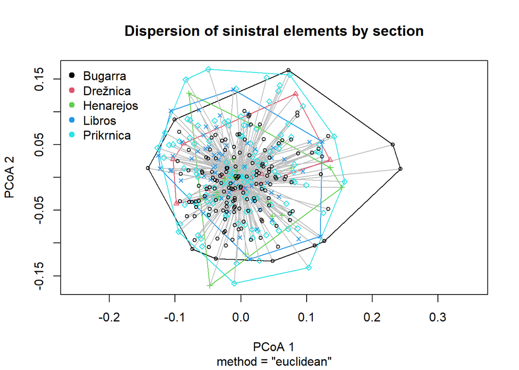

Dispersion of sinistral elements by section

```r
plot(bd_Sinistral_Section,
     main = "Dispersion of sinistral elements by section",
     label = FALSE)

legend("topleft",
       legend = levels(bd_Sinistral_Section$group),
       col = 1:length(levels(bd_Sinistral_Section$group)),
       pch = 19,
       bty = "n")
```

```r
tapply(
  bd_Sinistral_Section$distances,
  bd_Sinistral_Section$group,
  mean)
```

```
##    Bugarra   Drežnica  Henarejos     Libros  Prikrnica
## 0.08955924 0.10027035 0.09857588 0.09690972 0.10596814
```

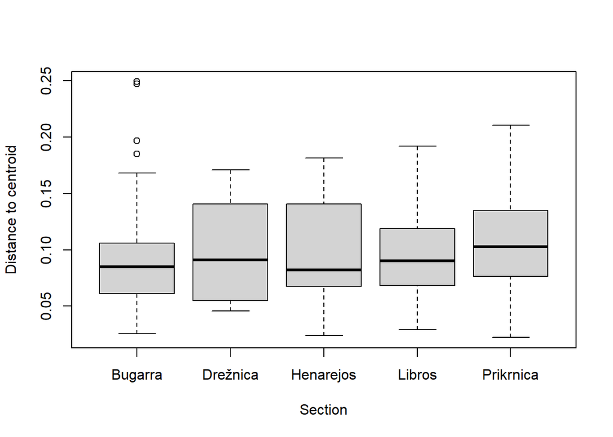

Within-section morphological disparity of sinistral elements

```r
boxplot(
  bd_Sinistral_Section$distances ~ bd_Sinistral_Section$group,
  ylab = "Distance to centroid",
  xlab = "Section")
```

Sinistral elements show significantly different shape dispersion.

```r
# The number of analysed sinistral elements differed between section, and resampling method was employed
sin_data <- subset(data_combined, Chirality == "Sinistral")
run_Section_dispersion <- function(df, n_sample = 10){

  replicate(500, {

    keep <- unlist(
      lapply(levels(df$Section), function(reg){

        idx <- which(df$Section == reg)

        if(length(idx) > n_sample){
          sample(idx, n_sample)
        } else {
          idx
        }

      })
    )

    bd <- betadisper(
      dist(df[keep, paste0("PC",1:7)]),
      group = df$Section[keep]
    )

    test <- permutest(
      bd,
      permutations = 999
    )

    test$tab$`Pr(>F)`[1]

  })
}


set.seed(42)
results_sin_disp_sect <- run_Section_dispersion(sin_data)

mean(results_sin_disp_sect < 0.05)
```

```
## [1] 0.018
```

The difference in multivariate dispersion remained significant only in low number of % of iterations, indication that disparity within section is highly dependent on sample size.

#### Dextral

```r
bd_Dextral_Section <- betadisper(
  dist(PC_scores[specimen_info_matched$Chirality == "Dextral", ]),
  group = specimen_info_matched$Section[specimen_info_matched$Chirality == "Dextral"]
)
set.seed(42)
permutest(bd_Dextral_Section)
```

```
##
## Permutation test for homogeneity of multivariate dispersions
## Permutation: free
## Number of permutations: 999
##
## Response: Distances
##            Df  Sum Sq   Mean Sq      F N.Perm Pr(>F)
## Groups      4 0.00678 0.0016947 0.9484    999  0.436
## Residuals 305 0.54498 0.0017868
```

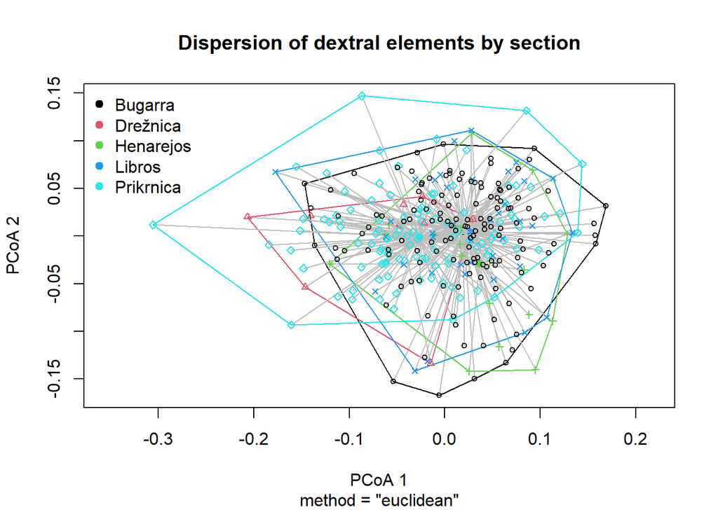

Dispersion of dextral elements by section

```r
plot(bd_Dextral_Section, main = "Dispersion of dextral elements by section",
     label = FALSE)

legend("topleft",
       legend = levels(bd_Dextral_Section$group),
       col = 1:length(levels(bd_Dextral_Section$group)),
       pch = 19,
       bty = "n")
```

```r
tapply(
  bd_Dextral_Section$distances,
  bd_Dextral_Section$group,
  mean
)
```

```
##    Bugarra   Drežnica  Henarejos     Libros  Prikrnica
## 0.09121500 0.10469154 0.10463524 0.09657179 0.09988836
```

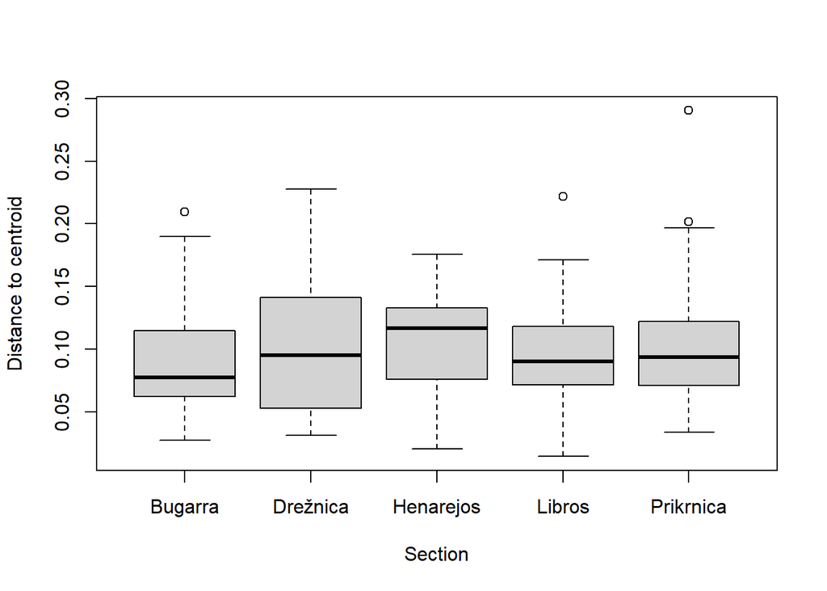

Within-section morphological disparity of dextral elements

```r
boxplot(
  bd_Dextral_Section$distances ~ bd_Dextral_Section$group,
  ylab = "Distance to centroid",
  xlab = "Section")
```

```r
# The number of analysed dextral elements differed between section, and resampling method was employed
dex_data <- subset(data_combined, Chirality == "Dextral")

run_Section_dispersion_dex <- function(df, n_sample = 8){

  replicate(500, {

    keep <- unlist(
      lapply(levels(df$Section), function(reg){

        idx <- which(df$Section == reg)

        if(length(idx) > n_sample){
          sample(idx, n_sample)
        } else {
          idx
        }

      })
    )

    bd <- betadisper(
      dist(df[keep, paste0("PC",1:7)]),
      group = df$Section[keep]
    )

    test <- permutest(
      bd,
      permutations = 999
    )

    test$tab$`Pr(>F)`[1]

  })
}


set.seed(42)
results_dex_disp_sect <- run_Section_dispersion_dex(dex_data)

mean(results_dex_disp_sect < 0.05)
```

```
## [1] 0.004
```

The difference in multivariate dispersion remained significant in low % of iterations. Observed regional differences and higher morphological variability of NE likely occur because of sample size between section.

# Analyses

## Length

### Chirality

```r
stats::kruskal.test(Length ~ Chirality, data = data_combined)
```

```
##
##  Kruskal-Wallis rank sum test
##
## data:  Length by Chirality
## Kruskal-Wallis chi-squared = 1.6926, df = 1, p-value = 0.1933
```

```r
aggregate(Length ~ Chirality, data = data_combined, mean)
```

```
##   Chirality   Length
## 1 Sinistral 402.7021
## 2   Dextral 394.9000
```

Based on Kruskal Wallis test the difference in length between sinistral and dextral is not significant so, we will group them all together when comparing length between different groups (region, section).

### Region

```r
aggregate(Length ~ Region, data = data_combined, mean)
```

```
##         Region   Length
## 1      Western 397.0680
## 2 Northeastern 402.6261
```

```r
kruskal.test(Length ~ Region, data = data_combined)
```

```
##
##  Kruskal-Wallis rank sum test
##
## data:  Length by Region
## Kruskal-Wallis chi-squared = 0.53537, df = 1, p-value = 0.4644
```

Based on Kruskal Wallis test the difference in length between regions is not significant.

### Section

```r
aggregate(Length ~ Section, data = data_combined, mean)
```

```
##     Section   Length
## 1 Henarejos 403.3613
## 2    Libros 403.5743
## 3   Bugarra 394.1093
## 4 Prikrnica 403.8841
## 5  Drežnica 386.8302
```

```r
kruskal.test(Length ~ Section, data = data_combined)
```

```
##
##  Kruskal-Wallis rank sum test
##
## data:  Length by Section
## Kruskal-Wallis chi-squared = 6.1269, df = 4, p-value = 0.1899
```

```r
dunn.test(data_combined$Length, g=data_combined$Section, method="bonferroni")
```

```
##   Kruskal-Wallis rank sum test
##
## data: x and group
## Kruskal-Wallis chi-squared = 6.1269, df = 4, p-value = 0.19
##
##
##                            Comparison of x by group
##                                  (Bonferroni)
## Col Mean-|
## Row Mean |    Bugarra   Drežnica   Henarejo     Libros
## ---------+--------------------------------------------
## Drežnica |   1.582179
##          |     0.5680
## Henarejo |   0.941654  -0.765290
##          |     1.0000     1.0000
##   Libros |  -0.725722  -1.828599  -1.290568
##          |     1.0000     0.3373     0.9843
## Prikrnic |  -1.123353  -1.975312  -1.487755  -0.119266
##          |     1.0000     0.2412     0.6841     1.0000
##
## alpha = 0.05
## Reject Ho if p <= alpha/2
```

Based on Kruskal Wallis test the difference in length between section is not significant. Pairwise post hoc comparisons using Dunn’s test with Bonferroni correction further supported this result, as none of the pairwise comparisons between sections are statistically significant.

### Length plot

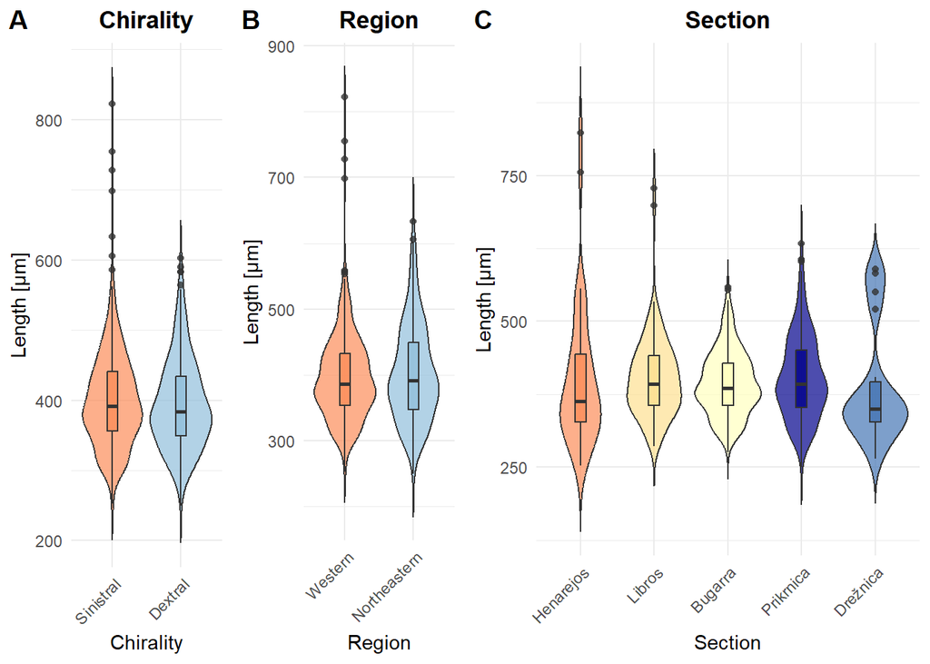

```r
plot_distance_violin <- function(data, group_var, colors, title = NULL) {
  ggplot(data, aes_string(x = group_var, y = "Length", fill = group_var)) +
    geom_violin(alpha = 0.7, trim = FALSE) +
    geom_boxplot(
      width = 0.15,
      alpha = 0.8,
      outlier.shape = 16,
      outlier.size = 1.5
    ) +
    theme_minimal() +
    scale_fill_manual(values = colors) +
    labs(
      x = group_var,
      y = "Length [μm]",
      title = title
    ) +
    theme(
      legend.position = "none",
      axis.text.x = element_text(angle = 45, hjust = 1),
      plot.title = element_text(face = "bold", hjust = 0.5)
    )
}

FZ_length <- plot_distance_violin(data_combined, "FaciesZone", colors_list$FaciesZone, "Facies Zone"
)
Region_length <- plot_distance_violin(data_combined, "Region", colors_list$Region,"Region"
)

Section_length <- plot_distance_violin( data_combined, "Section", colors_list$Section, "Section"
)

Chirality_length <- plot_distance_violin(data_combined, "Chirality", colors_list$Chirality, "Chirality"
)


ggarrange(
  Chirality_length,
  Region_length,
  Section_length,
  ncol = 3,
  widths = c(1, 1, 2),
  labels = c("A", "B", "C")
)
```

## Shape variation

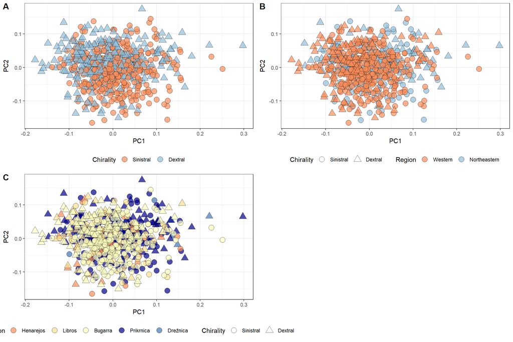

```r
pca1 <- ggplot(data_combined, aes(x = PC1, y = PC2,
                                  fill = Region,
                                  shape = Chirality)) +
  geom_point(size = 4, alpha = 0.7, color = "black") +
  scale_fill_manual(values = colors_list[["Region"]]) +
  scale_shape_manual(values = c("Sinistral" = 21,
                                "Dextral" = 24)) +
  labs(x = "PC1", y = "PC2",
       fill = "Region",
       shape = "Chirality") +
  guides(
    fill = guide_legend(override.aes = list(shape = 21)),
    shape = guide_legend(override.aes = list(fill = "white"))
  ) +
  theme_bw() +
  theme(legend.position = "bottom")


pca2 <- ggplot(data_combined, aes(x = PC1, y = PC2,
                                  fill = Section,
                                  shape = Chirality)) +
  geom_point(size = 4, alpha = 0.7, color = "black") +
  scale_fill_manual(values = colors_list[["Section"]]) +
  scale_shape_manual(values = c("Sinistral" = 21,
                                "Dextral" = 24)) +
  labs(x = "PC1", y = "PC2",
       fill = "Section",
       shape = "Chirality") +
  guides(
    fill = guide_legend(override.aes = list(shape = 21)),
    shape = guide_legend(override.aes = list(fill = "white"))
  ) +
  theme_bw() +
  theme(legend.position = "bottom")


pca3 <- ggplot(data_combined, aes(x = PC1, y = PC2,
                                  fill = Chirality,
                                  shape = Chirality)) +
  geom_point(size = 4, alpha = 0.7, color = "black") +
  scale_fill_manual(values = colors_list[["Chirality"]]) +
  scale_shape_manual(values = c("Sinistral" = 21,
                                "Dextral" = 24)) +
  labs(x = "PC1", y = "PC2",
       fill = "Chirality",
       shape = "Chirality") +
  guides(fill = guide_legend(override.aes = list(shape = 21))) +
  theme_bw() +
  theme(legend.position = "bottom")


ggarrange(pca3, pca1, pca2,
          labels = c("A", "B", "C"))
```

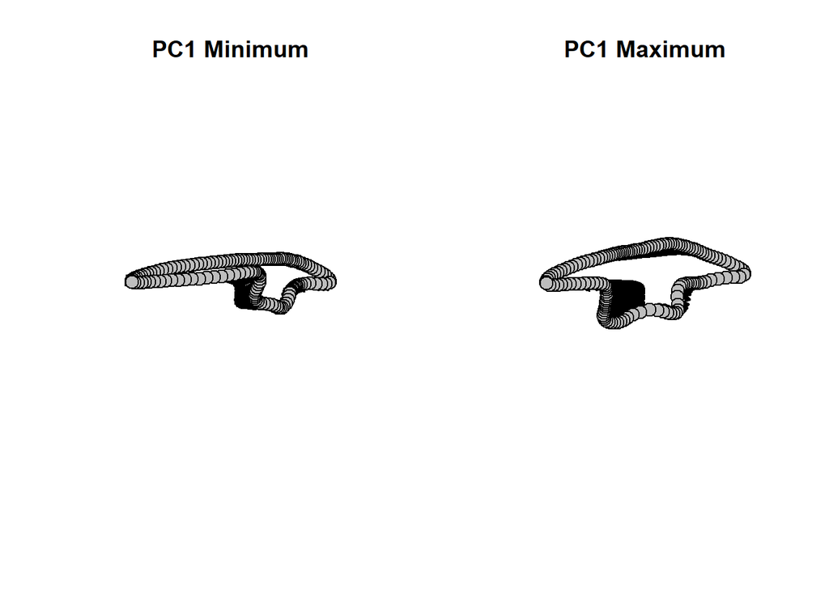

Shapes of extreme values of PC1

```r
par(mfrow = c(1, 2))

 # PC1 shape changes
geomorph::plotRefToTarget(PCA$shapes$shapes.comp1$min, msho, method = "vector",
                          main = "PC1 Minimum")
title(main = "PC1 Minimum")
geomorph::plotRefToTarget(PCA$shapes$shapes.comp1$max, msho, method = "vector",
                          main = "PC1 Maximum")
title(main = "PC1 Maximum")
```

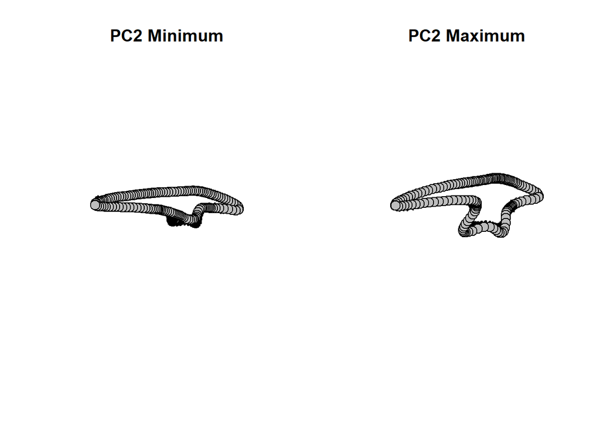

Shapes of extreme values of PC2

```r
par(mfrow = c(1, 2))
 # PC2 shape changes
geomorph::plotRefToTarget(PCA$shapes$shapes.comp2$min, msho, method = "vector",
                          main = "PC2 Minimum")
title(main = "PC2 Minimum")
geomorph::plotRefToTarget(PCA$shapes$shapes.comp2$max, msho, method = "vector",
                          main = "PC2 Maximum")
title(main = "PC2 Maximum")
```

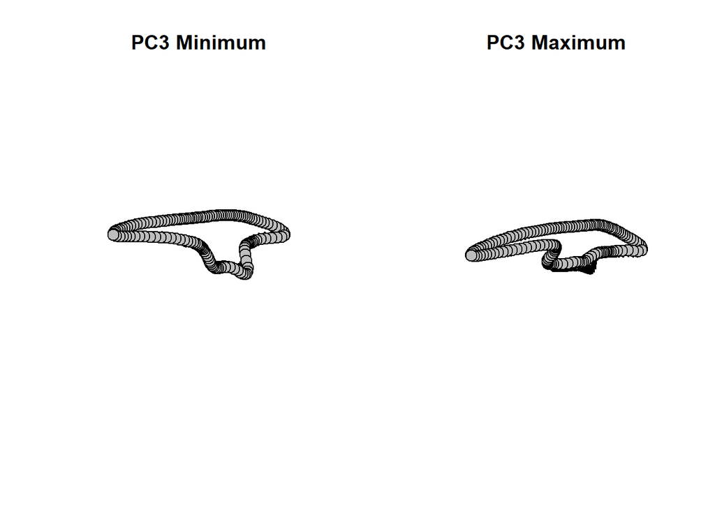

Shapes of extreme values of PC3

```r
par(mfrow = c(1, 2))
 # PC3 shape changes
geomorph::plotRefToTarget(PCA$shapes$shapes.comp3$min, msho, method = "vector",
                          main = "PC3 Minimum")
title(main = "PC3 Minimum")
geomorph::plotRefToTarget(PCA$shapes$shapes.comp3$max, msho, method = "vector",
                          main = "PC3 Maximum")
title(main = "PC3 Maximum")
```

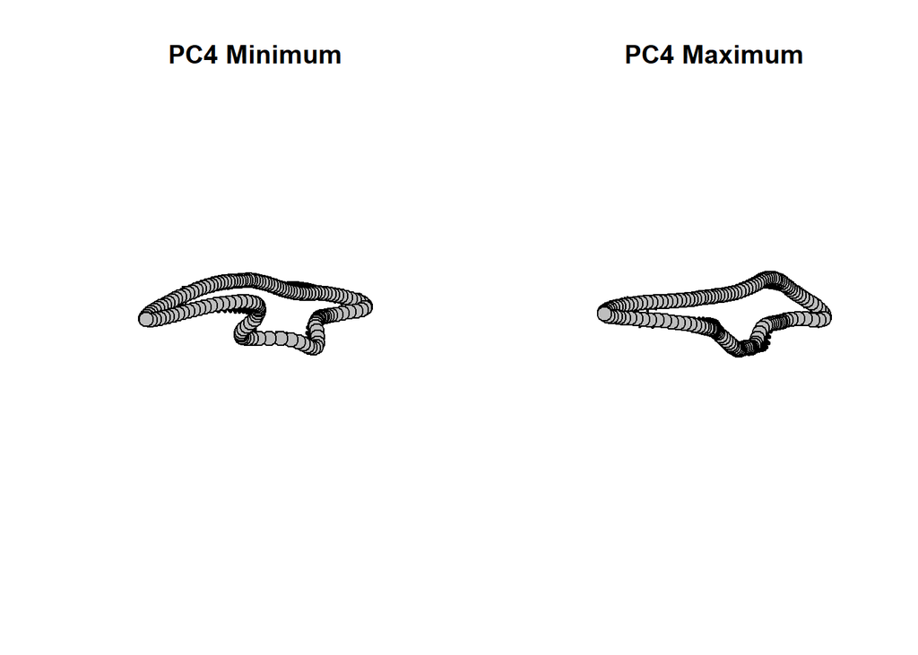

Shapes of extreme values of PC4

```r
par(mfrow = c(1, 2))
 # PC4 shape changes
geomorph::plotRefToTarget(PCA$shapes$shapes.comp4$min, msho, method = "vector",
                          main = "PC4 Minimum")
title(main = "PC4 Minimum")
geomorph::plotRefToTarget(PCA$shapes$shapes.comp4$max, msho, method = "vector",
                          main = "PC4 Maximum")
title(main = "PC4 Maximum")
```

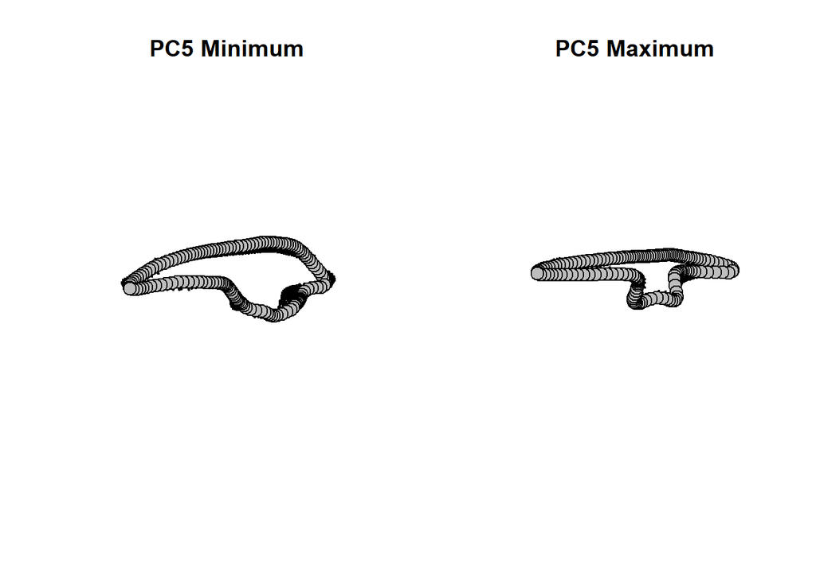

Shapes of extreme values of PC5

```r
par(mfrow = c(1, 2))
 # PC5 shape changes
geomorph::plotRefToTarget(PCA$shapes$shapes.comp5$min, msho, method = "vector",
                          main = "PC5 Minimum")
title(main = "PC5 Minimum")
geomorph::plotRefToTarget(PCA$shapes$shapes.comp5$max, msho, method = "vector",
                          main = "PC5 Maximum")
title(main = "PC5 Maximum")
```

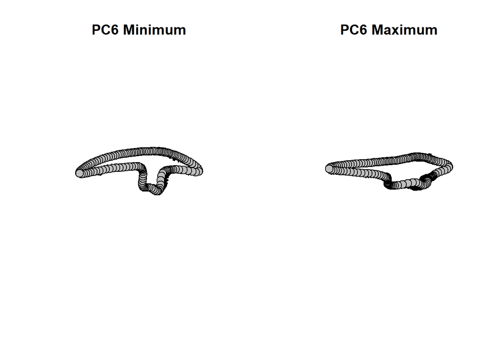

Shapes of extreme values of PC6

```r
par(mfrow = c(1, 2))
 # PC6 shape changes
geomorph::plotRefToTarget(PCA$shapes$shapes.comp6$min, msho, method = "vector",
                          main = "PC6 Minimum")
title(main = "PC6 Minimum")
geomorph::plotRefToTarget(PCA$shapes$shapes.comp6$max, msho, method = "vector",
                          main = "PC6 Maximum")
title(main = "PC6 Maximum")
```

```r
par(mfrow = c(1, 1))
```

## Statistical test

### Chirality

```r
set.seed(42)
adonis2(
  PC_scores ~ Chirality,
  data = data_combined,
  method = "euclidean",
  permutations = 9999,
)
```

```
## Permutation test for adonis under reduced model
## Permutation: free
## Number of permutations: 9999
##
## adonis2(formula = PC_scores ~ Chirality, data = data_combined, permutations = 9999, method = "euclidean")
##           Df SumOfSqs      R2      F Pr(>F)
## Model      1   0.6333 0.07607 54.997  1e-04 ***
## Residual 668   7.6918 0.92393
## Total    669   8.3250 1.00000
## ---
## Signif. codes:  0 '***' 0.001 '**' 0.01 '*' 0.05 '.' 0.1 ' ' 1
```

PERMANOVA showed a significant difference in shape between sinistral and dextral.

### Region

#### Sinistral

```r
set.seed(42)
adonis_Sinistral <- adonis2(
  PC_scores[specimen_info_matched$Chirality == "Sinistral", ] ~ Region,
  data = data_combined[specimen_info_matched$Chirality == "Sinistral", ],
  method = "euclidean",
  permutations = 9999
)
adonis_Sinistral
```

```
## Permutation test for adonis under reduced model
## Permutation: free
## Number of permutations: 9999
##
## adonis2(formula = PC_scores[specimen_info_matched$Chirality == "Sinistral", ] ~ Region, data = data_combined[specimen_info_matched$Chirality == "Sinistral", ], permutations = 9999, method = "euclidean")
##           Df SumOfSqs      R2      F Pr(>F)
## Model      1   0.0275 0.00683 2.4613 0.0436 *
## Residual 358   3.9967 0.99317
## Total    359   4.0241 1.00000
## ---
## Signif. codes:  0 '***' 0.001 '**' 0.01 '*' 0.05 '.' 0.1 ' ' 1
```

Shape variation of sinistral elements among regions differs significantly. However disparity test shows significant differences to (see Exploratory data analysis - informative PCs - Region - Sinistral), therefore, differences between regions reflect both variation in average shape configuration and differences in the range of shape variability

#### Dextral

```r
set.seed(42)
adonis_Dextral <- adonis2(
  PC_scores[specimen_info_matched$Chirality == "Dextral", ] ~ Region,
  data = data_combined[specimen_info_matched$Chirality == "Dextral", ],
  method = "euclidean",
  permutations = 9999
)

adonis_Dextral
```

```
## Permutation test for adonis under reduced model
## Permutation: free
## Number of permutations: 9999
##
## adonis2(formula = PC_scores[specimen_info_matched$Chirality == "Dextral", ] ~ Region, data = data_combined[specimen_info_matched$Chirality == "Dextral", ], permutations = 9999, method = "euclidean")
##           Df SumOfSqs      R2      F Pr(>F)
## Model      1   0.2046 0.05579 18.198  1e-04 ***
## Residual 308   3.4630 0.94421
## Total    309   3.6676 1.00000
## ---
## Signif. codes:  0 '***' 0.001 '**' 0.01 '*' 0.05 '.' 0.1 ' ' 1
```

Shape variation of dextral elements among regions differs significantly. Disparity test shows no significant differences between region (see Exploratory data analysis - informative PCs - Region - Sinistral), therefore, differences between regions reflect average shape configuration.

### Section

#### Sinistral

```r
set.seed(42)
adonis_Sinistral <- adonis2(
  PC_scores[specimen_info_matched$Chirality == "Sinistral", ] ~ Section,
  data = data_combined[specimen_info_matched$Chirality == "Sinistral", ],
  method = "euclidean",
  permutations = 9999
)
adonis_Sinistral
```

```
## Permutation test for adonis under reduced model
## Permutation: free
## Number of permutations: 9999
##
## adonis2(formula = PC_scores[specimen_info_matched$Chirality == "Sinistral", ] ~ Section, data = data_combined[specimen_info_matched$Chirality == "Sinistral", ], permutations = 9999, method = "euclidean")
##           Df SumOfSqs      R2      F Pr(>F)
## Model      4   0.1055 0.02621 2.3889 0.0025 **
## Residual 355   3.9187 0.97379
## Total    359   4.0241 1.00000
## ---
## Signif. codes:  0 '***' 0.001 '**' 0.01 '*' 0.05 '.' 0.1 ' ' 1
```

```r
set.seed(42)
pairwise_results_Section <- pairwise.adonis2(
  PC_scores[specimen_info_matched$Chirality == "Sinistral", ] ~ Section,
  data = data_combined[specimen_info_matched$Chirality == "Sinistral", ],
  method = "euclidean",
  permutations = 9999
)
pairwise_results_Section
```

```
## $parent_call
## [1] "PC_scores[specimen_info_matched$Chirality == \"Sinistral\", ] ~ Section , strata = Null , permutations 999"
##
## $Drežnica_vs_Prikrnica
##           Df SumOfSqs     R2      F Pr(>F)
## Model      1  0.01239 0.0076 0.9646  0.423
## Residual 126  1.61824 0.9924
## Total    127  1.63063 1.0000
##
## $Drežnica_vs_Henarejos
##          Df SumOfSqs     R2      F Pr(>F)
## Model     1  0.01259 0.0371 1.0019 0.4091
## Residual 26  0.32667 0.9629
## Total    27  0.33925 1.0000
##
## $Drežnica_vs_Libros
##          Df SumOfSqs      R2     F Pr(>F)
## Model     1  0.01153 0.01547 1.037 0.3706
## Residual 66  0.73413 0.98453
## Total    67  0.74566 1.00000
##
## $Drežnica_vs_Bugarra
##           Df SumOfSqs      R2      F Pr(>F)
## Model      1  0.02386 0.01478 2.4607 0.0448 *
## Residual 164  1.58992 0.98522
## Total    165  1.61377 1.00000
## ---
## Signif. codes:  0 '***' 0.001 '**' 0.01 '*' 0.05 '.' 0.1 ' ' 1
##
## $Prikrnica_vs_Henarejos
##           Df SumOfSqs      R2      F Pr(>F)
## Model      1  0.01227 0.00712 0.9611 0.3991
## Residual 134  1.71138 0.99288
## Total    135  1.72365 1.00000
##
## $Prikrnica_vs_Libros
##           Df SumOfSqs      R2      F Pr(>F)
## Model      1  0.03041 0.01415 2.4976 0.0432 *
## Residual 174  2.11884 0.98585
## Total    175  2.14925 1.00000
```

[output cut: 20 more lines]

```
##           Df SumOfSqs      R2      F Pr(>F)
## Model      1  0.01264 0.00746 1.2919 0.2615
## Residual 172  1.68305 0.99254
## Total    173  1.69569 1.00000
##
## $Libros_vs_Bugarra
##           Df SumOfSqs      R2     F Pr(>F)
## Model      1  0.04998 0.02335 5.069 0.0011 **
## Residual 212  2.09051 0.97665
## Total    213  2.14050 1.00000
## ---
## Signif. codes:  0 '***' 0.001 '**' 0.01 '*' 0.05 '.' 0.1 ' ' 1
##
## attr(,"class")
## [1] "pwadstrata" "list"
```

```r
# The number of analysed sinistral elements differed between section, and resampling method was employed

run_Section_test <- function(df, n_sample = 10){

  replicate(500, {

    keep <- unlist(
      lapply(levels(df$Section), function(sec){

        idx <- which(df$Section == sec)

        if(length(idx) > n_sample){
          sample(idx, n_sample)
        } else {
          idx
        }

      })
    )

    test <- adonis2(
      dist(df[keep, paste0("PC",1:7)]) ~ Section,
      data = df[keep, ],
      permutations = 999
    )

    test$`Pr(>F)`[1]

  })
}


results_sin_section <- run_Section_test(sin_data)

mean(results_sin_section < 0.05)
```

```
## [1] 0.146
```

Sinistral elements significantly differ in shape among sections. To evaluate whether the differences in morphological variability were associated with unequal sam-ple size among sections, in 500 iterations, specimens were randomly subsampled within each section (10 samples per section) and differences in multivariate dispersion and average shape configuration were reassessed.

#### Dextral

```r
set.seed(42)
adonis_Sinistral <- adonis2(
  PC_scores[specimen_info_matched$Chirality == "Dextral", ] ~ Section,
  data = data_combined[specimen_info_matched$Chirality == "Dextral", ],
  method = "euclidean",
  permutations = 9999
)
adonis_Sinistral
```

```
## Permutation test for adonis under reduced model
## Permutation: free
## Number of permutations: 9999
##
## adonis2(formula = PC_scores[specimen_info_matched$Chirality == "Dextral", ] ~ Section, data = data_combined[specimen_info_matched$Chirality == "Dextral", ], permutations = 9999, method = "euclidean")
##           Df SumOfSqs      R2      F Pr(>F)
## Model      4   0.2749 0.07494 6.1771  1e-04 ***
## Residual 305   3.3928 0.92506
## Total    309   3.6676 1.00000
## ---
## Signif. codes:  0 '***' 0.001 '**' 0.01 '*' 0.05 '.' 0.1 ' ' 1
```

```r
pairwise_results_Section <- pairwise.adonis2(
  PC_scores[specimen_info_matched$Chirality == "Dextral", ] ~ Section,
  data = data_combined[specimen_info_matched$Chirality == "Dextral", ],
  method = "euclidean",
  permutations = 9999
)
pairwise_results_Section
```

```
## $parent_call
## [1] "PC_scores[specimen_info_matched$Chirality == \"Dextral\", ] ~ Section , strata = Null , permutations 999"
##
## $Drežnica_vs_Prikrnica
##           Df SumOfSqs      R2      F Pr(>F)
## Model      1  0.02949 0.02109 2.4564 0.0548 .
## Residual 114  1.36865 0.97891
## Total    115  1.39814 1.00000
## ---
## Signif. codes:  0 '***' 0.001 '**' 0.01 '*' 0.05 '.' 0.1 ' ' 1
##
## $Drežnica_vs_Henarejos
##          Df SumOfSqs      R2      F Pr(>F)
## Model     1  0.07467 0.17605 5.3418 0.0013 **
## Residual 25  0.34947 0.82395
## Total    26  0.42414 1.00000
## ---
## Signif. codes:  0 '***' 0.001 '**' 0.01 '*' 0.05 '.' 0.1 ' ' 1
##
## $Drežnica_vs_Libros
##          Df SumOfSqs      R2     F Pr(>F)
## Model     1  0.07509 0.12369 6.352  7e-04 ***
## Residual 45  0.53196 0.87631
## Total    46  0.60705 1.00000
## ---
## Signif. codes:  0 '***' 0.001 '**' 0.01 '*' 0.05 '.' 0.1 ' ' 1
##
## $Drežnica_vs_Bugarra
##           Df SumOfSqs      R2      F Pr(>F)
## Model      1  0.06803 0.04415 6.5595  8e-04 ***
## Residual 142  1.47278 0.95585
## Total    143  1.54081 1.00000
## ---
## Signif. codes:  0 '***' 0.001 '**' 0.01 '*' 0.05 '.' 0.1 ' ' 1
##
## $Prikrnica_vs_Henarejos
##           Df SumOfSqs      R2      F Pr(>F)
## Model      1  0.08608 0.05434 7.1824  3e-04 ***
## Residual 125  1.49805 0.94566
## Total    126  1.58413 1.00000
```

[output cut: 26 more lines]

```
##           Df SumOfSqs      R2      F Pr(>F)
## Model      1  0.02836 0.01739 2.7079 0.0367 *
## Residual 153  1.60219 0.98261
## Total    154  1.63054 1.00000
## ---
## Signif. codes:  0 '***' 0.001 '**' 0.01 '*' 0.05 '.' 0.1 ' ' 1
##
## $Libros_vs_Bugarra
##           Df SumOfSqs      R2      F Pr(>F)
## Model      1  0.01423 0.00791 1.3794 0.2284
## Residual 173  1.78468 0.99209
## Total    174  1.79891 1.00000
##
## attr(,"class")
## [1] "pwadstrata" "list"
```

```r
# The number of analysed dextral elements differed between section, and resampling method was employed

run_Section_test_dex <- function(df, n_sample = 8){

  replicate(500, {

    keep <- unlist(
      lapply(levels(df$Section), function(sec){

        idx <- which(df$Section == sec)

        if(length(idx) > n_sample){
          sample(idx, n_sample)
        } else {
          idx
        }

      })
    )

    test <- adonis2(
      dist(df[keep, paste0("PC",1:7)]) ~ Section,
      data = df[keep, ],
      permutations = 999
    )

    test$`Pr(>F)`[1]

  })
}


results_dex_section <- run_Section_test_dex(dex_data)

mean(results_dex_section < 0.05)
```

```
## [1] 0.84
```

Dextral elements shape differs significantly among sections. However here to the sample size varies between section.

A resampling approach applied to PERMANOVA showed that differences of dextral elements in multivariate shape among sections remains significant in high % of 500 iteration. Consequently, the observed differences among sections reflect average shape configuration.

## Mean shape

### Chirality

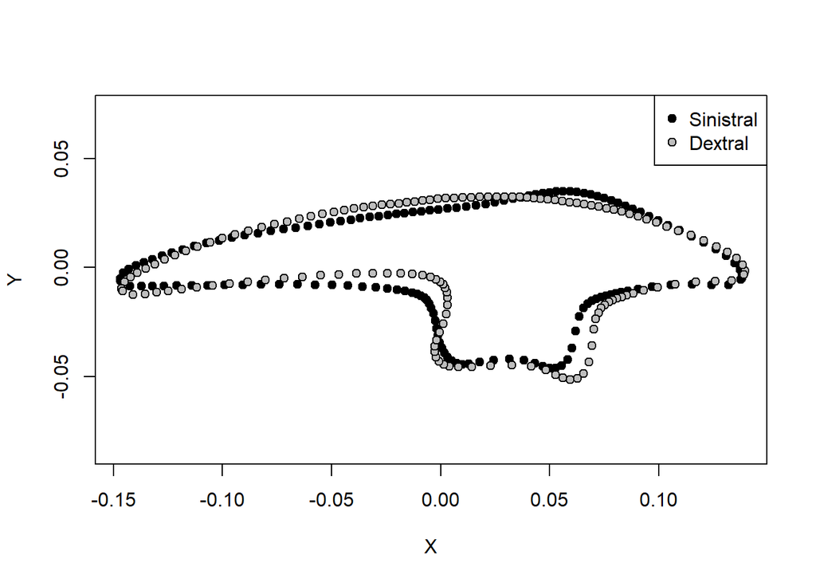

Mean shapes of Sinistral and Dextral elements

```r
mean_shape_Sinistral <- geomorph::mshape(landmarks.gpa$coords[, , specimen_info_matched$Chirality == "Sinistral"])
mean_shape_Dextral <- geomorph::mshape(landmarks.gpa$coords[, , specimen_info_matched$Chirality == "Dextral"])



plot(
  mean_shape_Sinistral[,1],
  mean_shape_Sinistral[,2],
  asp = 1,
  type = "n",
  xlab = "X",
  ylab = "Y"
)
points(mean_shape_Sinistral[,1], mean_shape_Sinistral[,2],
       pch=21, bg="black")

points(mean_shape_Dextral[,1], mean_shape_Dextral[,2],
       pch=21, bg="grey")

legend(
  "topright",
  legend=c("Sinistral","Dextral"),
  pch=21,
  pt.bg=c("black","grey")
)
```

### Regions

```r
mean_shape_W_Sinistral <- geomorph::mshape(
  landmarks.gpa$coords[, , specimen_info_matched$Region == "Western" &
                         specimen_info_matched$Chirality == "Sinistral"]
)

mean_shape_W_Dextral <- geomorph::mshape(
  landmarks.gpa$coords[, , specimen_info_matched$Region == "Western" &
                         specimen_info_matched$Chirality == "Dextral"]
)

mean_shape_N_Sinistral <- geomorph::mshape(
  landmarks.gpa$coords[, , specimen_info_matched$Region == "North-Eastern" &
                         specimen_info_matched$Chirality == "Sinistral"]
)

mean_shape_N_Dextral <- geomorph::mshape(
  landmarks.gpa$coords[, , specimen_info_matched$Region == "North-Eastern" &
                         specimen_info_matched$Chirality == "Dextral"]
)
```

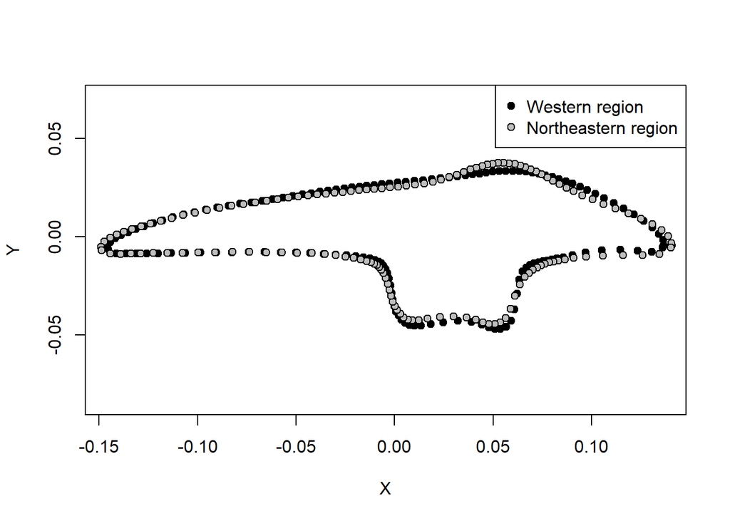

Mean shapes of sinistral elements across regions

```r
plot(
  mean_shape_W_Sinistral[,1],
  mean_shape_W_Sinistral[,2],
  asp = 1,
  type = "n",
  xlab = "X",
  ylab = "Y"
)
points(mean_shape_W_Sinistral[,1], mean_shape_W_Sinistral[,2],
       pch=21, bg="black")

points(mean_shape_N_Sinistral[,1], mean_shape_N_Sinistral[,2],
       pch=21, bg="grey")

legend(
  "topright",
  legend=c("Western region","Northeastern region"),
  pch=21,
  pt.bg=c("black","grey")
)
```

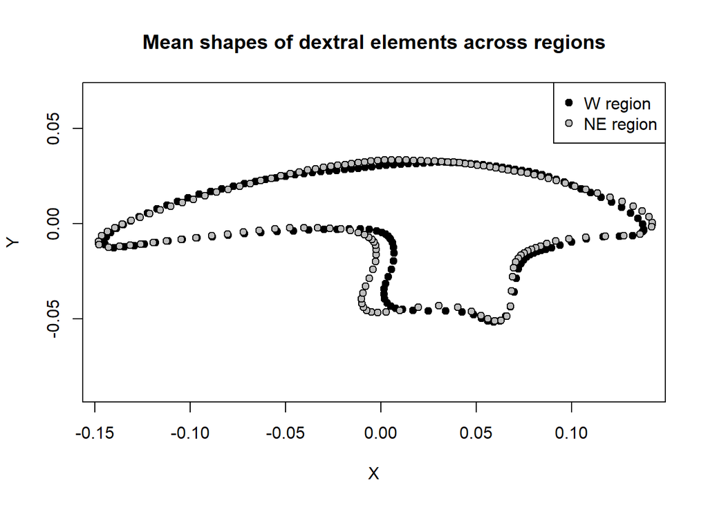

Mean shapes of dextral elements across regions

```r
plot(
  mean_shape_W_Dextral[,1],
  mean_shape_W_Dextral[,2],
  asp = 1,
  type = "n",
  xlab = "X",
  ylab = "Y",
  main = "Mean shapes of dextral elements across regions"
)
points(mean_shape_W_Dextral[,1], mean_shape_W_Dextral[,2],
       pch=21, bg="black")

points(mean_shape_N_Dextral[,1], mean_shape_N_Dextral[,2],
       pch=21, bg="grey")

legend(
  "topright",
  legend=c("W region","NE region"),
  pch=21,
  pt.bg=c("black","grey")
)
```

### Section

```r
mean_shape_Henarejos_L <- geomorph::mshape(
  landmarks.gpa$coords[, , specimen_info_matched$Section == "Henarejos" &
                         specimen_info_matched$Chirality == "Sinistral"]
)

mean_shape_Libros_L <- geomorph::mshape(
  landmarks.gpa$coords[, , specimen_info_matched$Section == "Libros" &
                         specimen_info_matched$Chirality == "Sinistral"]
)

mean_shape_Bugarra_L <- geomorph::mshape(
  landmarks.gpa$coords[, , specimen_info_matched$Section == "Bugarra" &
                         specimen_info_matched$Chirality == "Sinistral"]
)

mean_shape_Prikrnica_L <- geomorph::mshape(
  landmarks.gpa$coords[, , specimen_info_matched$Section == "Prikrnica" &
                         specimen_info_matched$Chirality == "Sinistral"]
)

mean_shape_Drežnica_L <- geomorph::mshape(
  landmarks.gpa$coords[, , specimen_info_matched$Section == "Drežnica" &
                         specimen_info_matched$Chirality == "Sinistral"]
)
mean_shape_Henarejos_R <- geomorph::mshape(
  landmarks.gpa$coords[, , specimen_info_matched$Section == "Henarejos" &
                         specimen_info_matched$Chirality == "Dextral"]
)

mean_shape_Libros_R <- geomorph::mshape(
  landmarks.gpa$coords[, , specimen_info_matched$Section == "Libros" &
                         specimen_info_matched$Chirality == "Dextral"]
)

mean_shape_Bugarra_R <- geomorph::mshape(
  landmarks.gpa$coords[, , specimen_info_matched$Section == "Bugarra" &
                         specimen_info_matched$Chirality == "Dextral"]
)

mean_shape_Prikrnica_R <- geomorph::mshape(
  landmarks.gpa$coords[, , specimen_info_matched$Section == "Prikrnica" &
                         specimen_info_matched$Chirality == "Dextral"]
)

mean_shape_Drežnica_R <- geomorph::mshape(
  landmarks.gpa$coords[, , specimen_info_matched$Section == "Drežnica" &
                         specimen_info_matched$Chirality == "Dextral"]
)
```

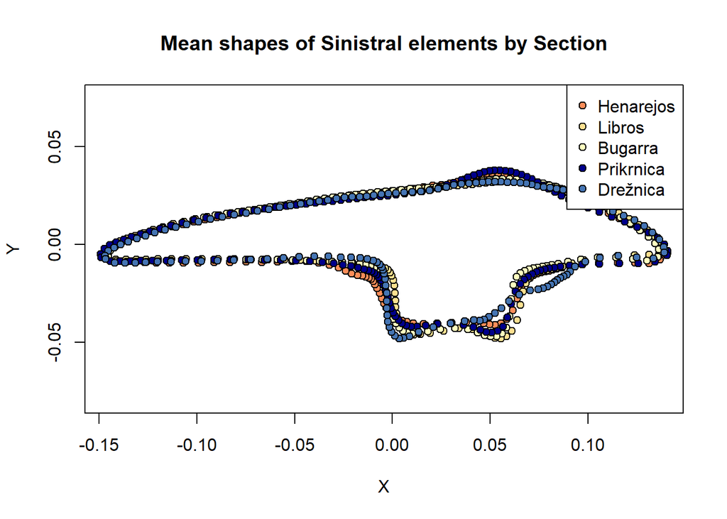

Mean shapes of sinistral elements across section

```r
plot(
  mean_shape_Henarejos_L[,1],
  mean_shape_Henarejos_L[,2],
  asp = 1,
  type = "n",
  xlab = "X",
  ylab = "Y",
  main = "Mean shapes of Sinistral elements by Section"
)

points(mean_shape_Henarejos_L[,1], mean_shape_Henarejos_L[,2],
       pch=21, bg="#fc8d59")

points(mean_shape_Libros_L[,1], mean_shape_Libros_L[,2],
       pch=21, bg="#fee090")

points(mean_shape_Bugarra_L[,1], mean_shape_Bugarra_L[,2],
       pch=21, bg="#ffffbf")

points(mean_shape_Prikrnica_L[,1], mean_shape_Prikrnica_L[,2],
       pch=21, bg="darkblue")

points(mean_shape_Drežnica_L[,1], mean_shape_Drežnica_L[,2],
       pch=21, bg="#4575b4")


legend(
  "topright",
  legend=c("Henarejos","Libros","Bugarra","Prikrnica","Drežnica"),
  pch=21,
  pt.bg=c("#fc8d59","#fee090","#ffffbf","darkblue","#4575b4")
)
```

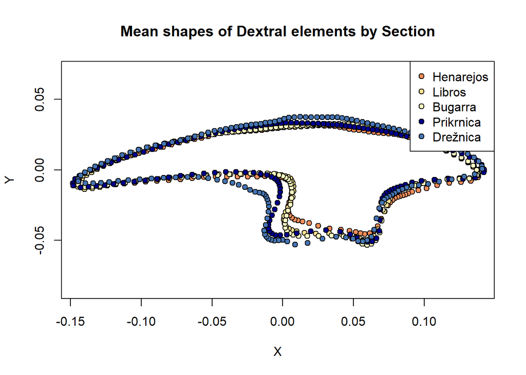

Mean shapes of dextral elements across section

```r
plot(
  mean_shape_Henarejos_R[,1],
  mean_shape_Henarejos_R[,2],
  asp = 1,
  type = "n",
  xlab = "X",
  ylab = "Y",
  main = "Mean shapes of Dextral elements by Section"
)

points(mean_shape_Henarejos_R[,1], mean_shape_Henarejos_R[,2],
       pch=21, bg="#fc8d59")

points(mean_shape_Libros_R[,1], mean_shape_Libros_R[,2],
       pch=21, bg="#fee090")

points(mean_shape_Bugarra_R[,1], mean_shape_Bugarra_R[,2],
       pch=21, bg="#ffffbf")

points(mean_shape_Prikrnica_R[,1], mean_shape_Prikrnica_R[,2],
       pch=21, bg="darkblue")

points(mean_shape_Drežnica_R[,1], mean_shape_Drežnica_R[,2],
       pch=21, bg="#4575b4")


legend(
  "topright",
  legend=c("Henarejos","Libros","Bugarra","Prikrnica","Drežnica"),
  pch=21,
  pt.bg=c("#fc8d59","#fee090","#ffffbf","darkblue","#4575b4")
)
```